# Assignment 6

November 26, 2020

Our textbook example demonstrated that according to the 2014-2018 PUMS data, about a third of households in the Bay Area were paying more than 30% of their income on housing, and the total amount of that housing cost above the 30% threshold, for all of those households combined, was almost $11 billion per year in 2018 dollars. The following analysis captures the difference between renters and those who own their homes in terms of housing burden. The following maps show housing burden differences between these two groups in the Bay Area and then more specifically in SF County.

**Housing Burden for Renters**

According to 2014-2018 PUMS data, nearly 47% of households that were renters in the Bay Area were paying more than 30% of their income on housing, and the total amount of that housing cost above the 30% threshold, for all of those households combined, was $5 billion per year in 2018 dollars.

```
## [1] 0.4687305
```

```
## [1] 5003652268
```

[interactive chart not shown]

**Housing Burden for Buyers**

According to 2014-2018 PUMS data, nearly 29% of households that were homeowners in the Bay Area were paying more than 30% of their income on housing, and the total amount of that housing cost above the 30% threshold, for all of those households combined, was almost $6 billion per year in 2018 dollars.

```
## [1] 0.2879063
```

```
## [1] 5985672523
```

[interactive chart not shown]

Here, you can see that renters account for much more of the housing burden (47%) in comparison to buyers (29%).

**Housing Burden for Renters in SF**

According to 2014-2018 PUMS data, nearly 37% of households that were renters in San Francisco County were paying more than 30% of their income on housing, and the total amount of that housing cost above the 30% threshold, for all of those households combined, was almost $730 million per year in 2018 dollars.

```
## [1] 0.3700683
```

```
## [1] 730905739
```

[interactive chart not shown]

**Housing Burden for Buyers in SF**

According to 2014-2018 PUMS data, nearly 29% of households that were buyers in San Francisco County were paying more than 30% of their income on housing, and the total amount of that housing cost above the 30% threshold, for all of those households combined, was almost $700 million per year in 2018 dollars.

```
## [1] 0.2865525
```

```
## [1] 685316479
```

[interactive chart not shown]

Here, you can see that in SF County, like the broader Bay Area, renters are accounting for much more of the housing burden when compared to buyers. However, the difference in % housing burden between renters and buyers is less than in the greater Bay Area.

**Dogpatch**

The following analysis looks at the Dogpatch neighborhood, an “up and coming” area of SF. This analysis shows the distribution of property uses under existing zoning and identifies where there is opportunity to build additional housing within the neighborhood.

The Dogpatch neighborhood is in ZN08 in SF, and appears to align closely with the SoMa NCT. Because it is mixed use, there may be more detailed height and density restrictions that could be analyzed at a more granular block by block level. However, for this analysis, SoMa NCT and UMU density and building heights will be used. Additionally, UMU areas have no density limit, so the higher 3.6 FAR is used, which is found elsewhere in the city. Because of this, the number of additional housing units that could be built is likely an underestimate for the neighborhood.

[interactive chart not shown]

```
## [1] 4121105
```

```
## [1] 1671
```

Based on current zoning, there is about 4 million square feet of floor area that could be built in this area, meaning the land is underutilized. This is a lot for a small residential and mixed use zoned area, though some of this mixed use space would realistically be used for non-residential uses (floor area is all assumed to be residential for the calculations). If that underutilized space were to be used for housing, there could be nearly 1,700 more dwelling units. If zoning were to be changed - converting some of the historically industrial land to residential- there is the opportunity for a lot more housing, as we have been seeing in the neighborhood over the last few years.

To visualize where there are opportunities for growth, the following maps show unused floor area, unused units and unused stories based on comparing what is currently there and what could be built there according to current zoning code. One interesting observation is that building height in the residentially zoned areas seems to already be utilizing more stories than in the areas zoned as non-residential. This may be skewed because industrial or multi-use buildings may have >11ft ceiling heights, meaning it looks like they have more unused space than they do.

[interactive chart not shown]

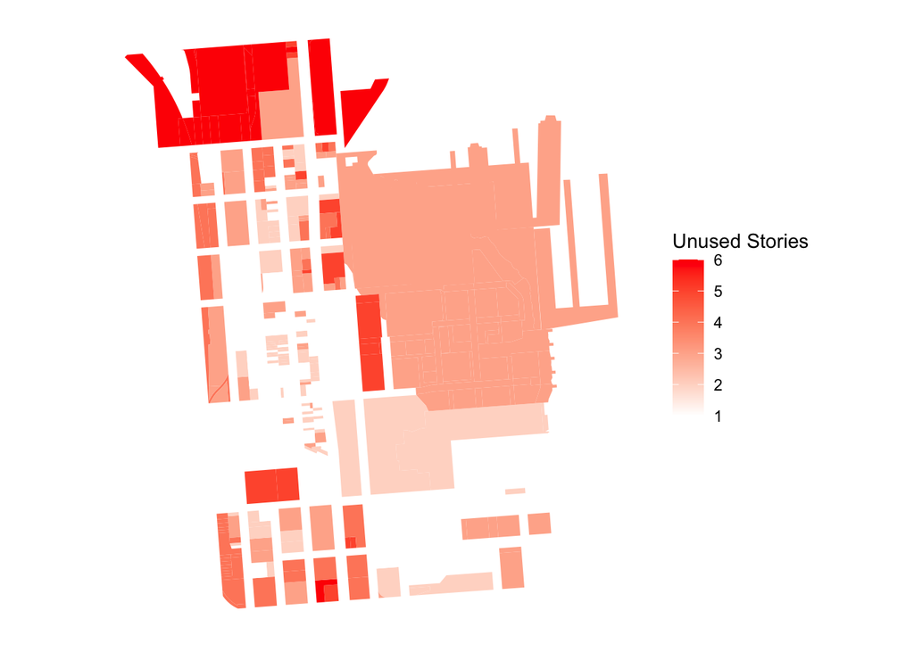